# Solution_Lab8

As a further exercise, we suggest to test the performance of the other regressors with the same preprocessing applied to improve the linear models. Let's test now what happens adding the Gaussian noise.

```
+------------------+--------------------+-----------------------+
|      model       |        MSE         |           R2          |
+------------------+--------------------+-----------------------+
|      linreg      | 13844.561167759284 | -0.015583193249441907 |
|      ridge       | 13844.460508413049 | -0.015575809271066499 |
|   mlp_standard   | 2991.1860609583377 |   0.7805782173532807  |
|    mlp_tuned     |  5787.52310195952  |   0.5754498014295486  |
|       svr        | 12891.137648265858 |  0.05435625016904311  |
|        rf        | 4113.044606937682  |   0.6982830351012688  |
| sin+poly5+linreg | 3314.773489446183  |   0.7568411013886113  |
| sin+poly5+ridge  |  3298.91855356633  |   0.7580041578563832  |
+------------------+--------------------+-----------------------+
```

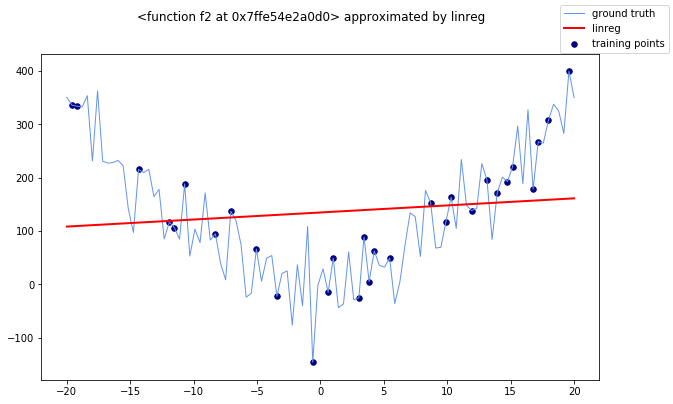

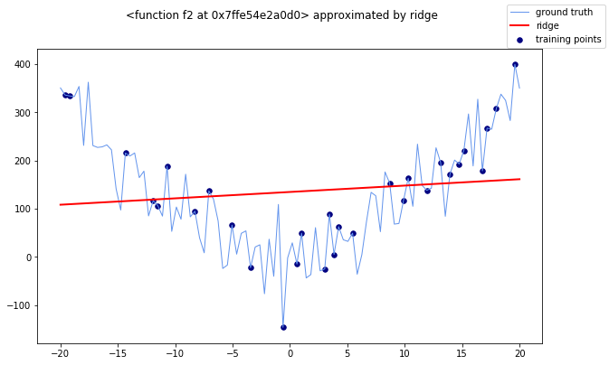

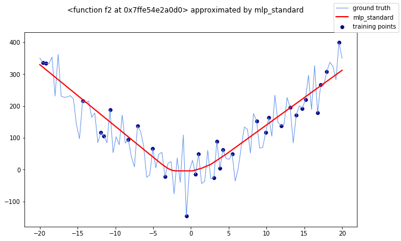

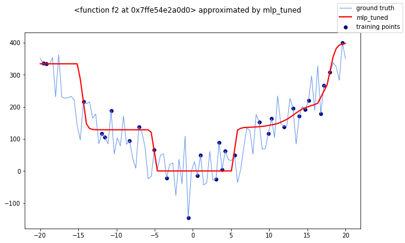

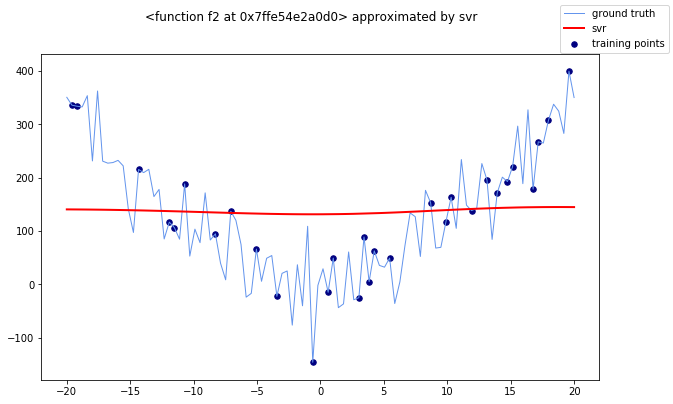

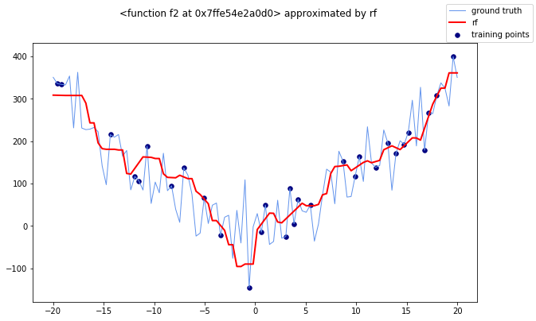

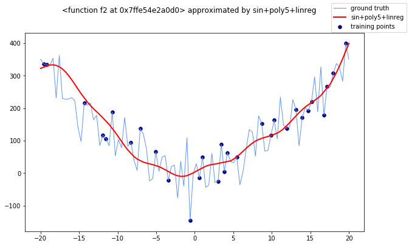

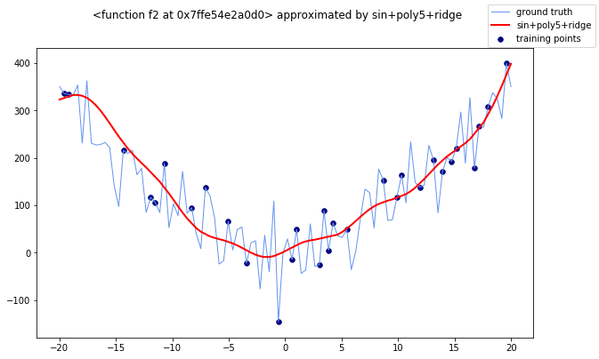

```python
X, y = generate_X_y(f2)
y = inject_noise(y)

t = PrettyTable()
t.field_names = ['model', 'MSE', 'R2']
for model, name in zip(models, names):
    mse, r2 = evaluate_model(f2, X, y, model, name)
    t.add_row([name, mse, r2])

print(t)
```

The overall shape of the function is retained by the standard MLP, and *sin+poly5+[linreg|ridge]*. This lead to the lowest overall error.

#### Results for f = f3

```
+------------------+--------------------+---------------------+
|      model       |        MSE         |          R2         |
+------------------+--------------------+---------------------+
|      linreg      | 15760.86079984127  |  0.9222471586304892 |
|      ridge       | 15763.614946346856 |  0.9222335716367915 |
|   mlp_standard   | 11102.721825876006 |  0.9452270926150279 |
|    mlp_tuned     | 13752.433310925047 |  0.9321553067913714 |
|       svr        | 326343.75456681015 | -0.6099472295967054 |
|        rf        | 2451.5507620247454 |  0.9879057977905031 |
| sin+poly5+linreg | 9562.724944229945  |  0.9528243383980357 |
| sin+poly5+ridge  |  9517.04484093962  |  0.9530496914336334 |
+------------------+--------------------+---------------------+
```

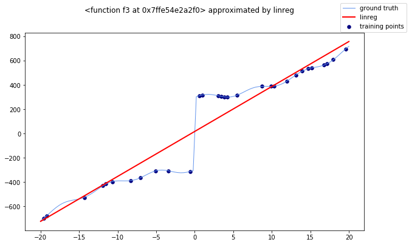

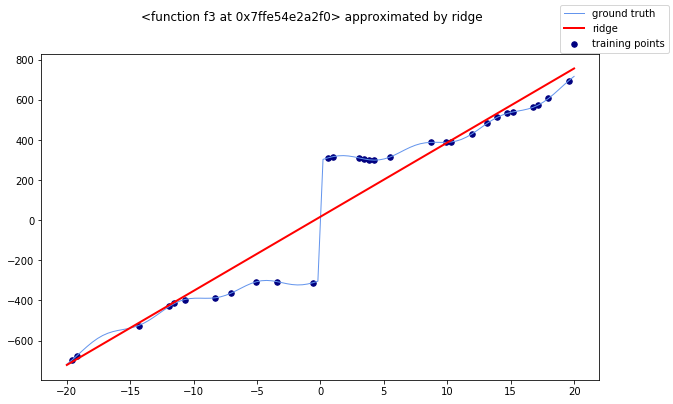

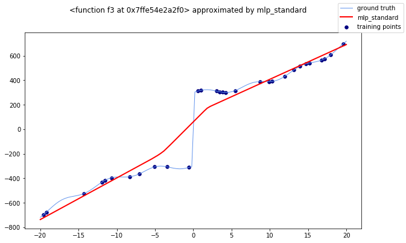

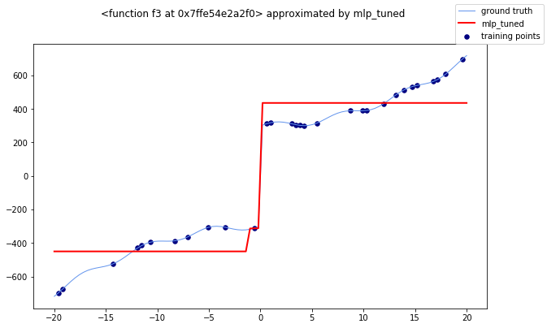

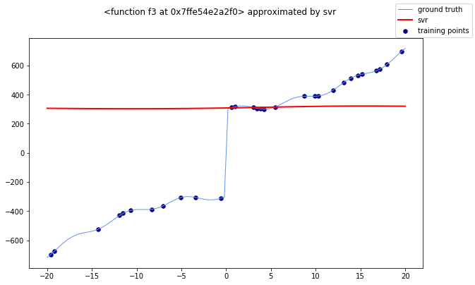

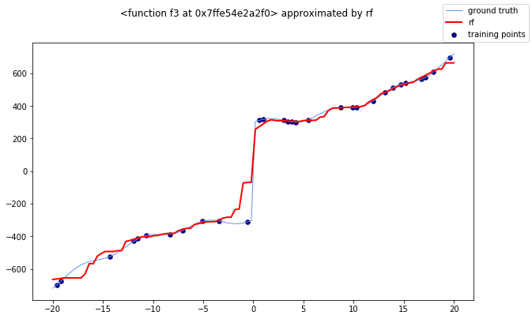

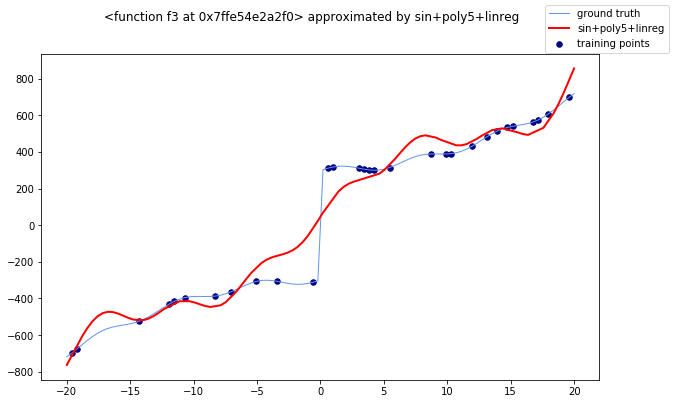

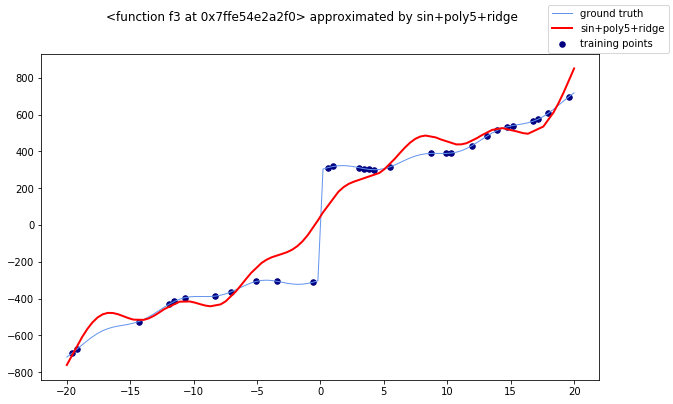

```python
t = PrettyTable()
t.field_names = ['model', 'MSE', 'R2']
X, y = generate_X_y(f3)
for model, name in zip(models, names):
    mse, r2 = evaluate_model(f3, X, y, model, name)
    t.add_row([name, mse, r2])

print(t)
```

The top performing algorithm is Random Forest again. We can see that it is the only model able to handle the discontinuity at 0: values approaching 0 from the left (small negative values) are similar to the real values of the left-most part of the function, the same applies for small positive values.

```
+------------------+--------------------+---------------------+
|      model       |        MSE         |          R2         |
+------------------+--------------------+---------------------+
|      linreg      | 17515.338908756312 |  0.9121094984003594 |
|      ridge       | 17517.105255078095 |  0.9121006350226635 |
|   mlp_standard   | 12352.939018232815 |  0.9380139880707941 |
|    mlp_tuned     | 22997.03282444203  |  0.8846028180914527 |
|       svr        | 305167.54329760035 | -0.5313051372901239 |
|        rf        | 6353.001176701917  |  0.9681211729334968 |
| sin+poly5+linreg | 11793.78421643006  |  0.9408197799688728 |
| sin+poly5+ridge  | 11650.803186975163 |  0.941537246782589  |
+------------------+--------------------+---------------------+
```

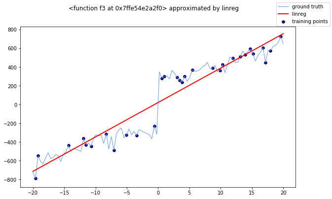

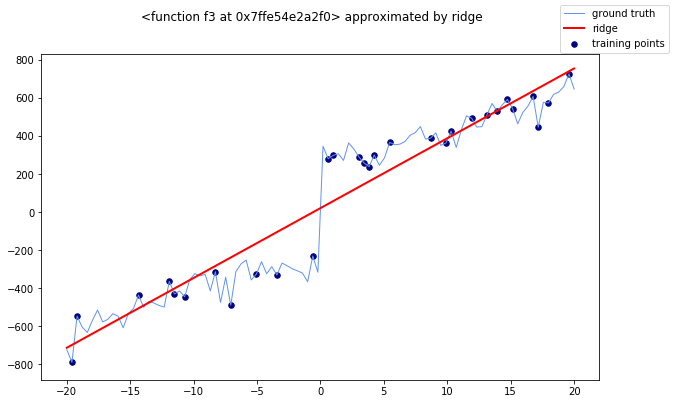

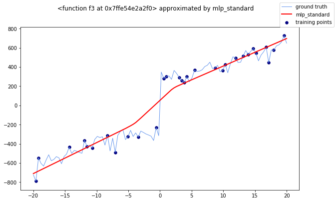

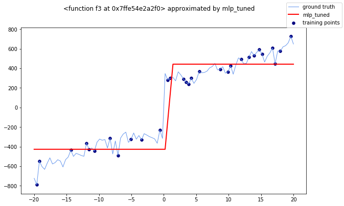

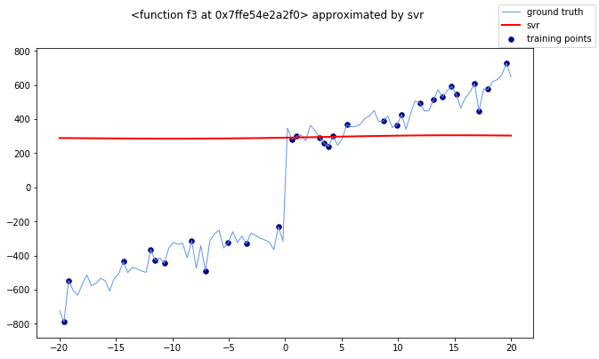

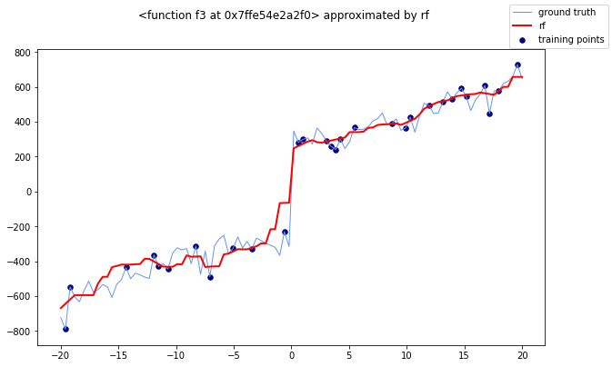

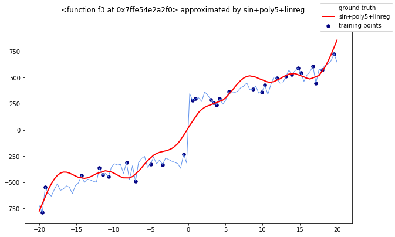

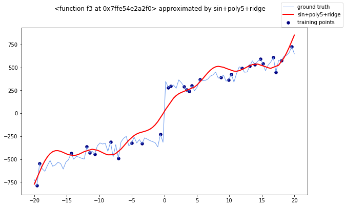

```python
X, y = generate_X_y(f3)
y = inject_noise(y)

t = PrettyTable()
t.field_names = ['model', 'MSE', 'R2']
for model, name in zip(models, names):
    mse, r2 = evaluate_model(f3, X, y, model, name)
    t.add_row([name, mse, r2])

print(t)
```

The most robust to noise is Random Forest in this case.

### Exercise 2

In this exercise, you will carry out a multivariate regression analysis. Technically speaking, the preprocessing step added in the pipeline in Exercise 1 also lead to a multivariate analyis, considering also the newly generated features. Now, we generate a synthetic, multi-dimensional dataset using scikit-learn. The nature and the importance of each of the features can be fine-tuned using the [make_regression](https://scikit-learn.org/stable/modules/generated/sklearn.datasets.make_regression.html) function.

```python
from sklearn.datasets import make_regression
```

### Exercise 2.1

We can use the `make_regression` function to generate a synthetic dataset with 2000 points. You should spend enough time inspecting the function parameters. For now, we recall that, by default:

- 100 features are generated, 10 of which are informative
- the target variable has a single dimension
- no noise is applied. You can set a normal noise with the parameter `noise`

```python
X, y = make_regression(n_samples=2000, random_state=42)
X.shape, y.shape
```

```
((2000, 100), (2000,))
```

### Exercise 2.2

We can now run again the regression simulation developed in Exercise 1.

Note: here we get back to the normal conditions where we adopt 70% of the dataset as training set and the remaining 30% as test set. This can be achieved by simply changing the value to the `train_size` parameter.

```python
t = PrettyTable()
t.field_names = ['model', 'MSE', 'R2']

for model, name in zip(models, names):
    X_train, X_test, y_train, y_test = train_test_split(X, y,
                                                    train_size=.7,
                                                    random_state=42,
                                                    shuffle=True)
    model.fit(X_train, y_train)
    y_hat = model.predict(X_test)
    mse = mean_squared_error(y_test, y_hat)
    r2 = r2_score(y_test, y_hat)
    t.add_row([name, mse, r2])

print(t)
```

```
+------------------+-----------------------+-----------------------+
|      model       |          MSE          |           R2          |
+------------------+-----------------------+-----------------------+
|      linreg      | 1.491861127842467e-25 |          1.0          |
|      ridge       |  0.026589221217723277 |   0.9999993361938854  |
|   mlp_standard   |   59.67097245363076   |   0.998510300243291   |
|    mlp_tuned     |   9081.738642192302   |   0.773272274785179   |
|       svr        |   38892.567627033684  |  0.029037970232504207 |
|        rf        |   10655.011193604842  |   0.7339951582793712  |
| sin+poly5+linreg |   40959.66218569419   | -0.022567527960504208 |
| sin+poly5+ridge  |    40620.5489939929   |  -0.01410148796816535 |
+------------------+-----------------------+-----------------------+
```

The tested model behave differently. Since the target label is generated by `make_regression` from a random linear model, we find that linear models and the model which can closely approximate a linear model (e.g. the standard MLP with one hidden layer) perform better. The R2 for the unregularized linear model is 1, meaning that it is able to capture all the information in the 10 informative features (the MSE is approximately 0).

Even though these results suggest that the so-defined problem is simple, we can notice that more complex models fail at grasping this simplicity, leading to high errors. Over-parametrized models strongly suffer the redundancy of information carried by the non-informative 90 features.

### Exercise 2.3

Let's now inspect how the performance of our models change when:

- some noise is introduced;
- the number of informative features increases.

```python
X, y = make_regression(n_samples=2000, random_state=42, noise=10)
t = PrettyTable()
t.field_names = ['model', 'MSE', 'R2']

for model, name in zip(models, names):
    X_train, X_test, y_train, y_test = train_test_split(X, y,
                                                    train_size=.7,
                                                    random_state=42,
                                                    shuffle=True)
    model.fit(X_train, y_train)
    y_hat = model.predict(X_test)
    mse = mean_squared_error(y_test, y_hat)
    r2 = r2_score(y_test, y_hat)
    t.add_row([name, mse, r2])

print(t)
```

```
+------------------+--------------------+-----------------------+
|      model       |        MSE         |           R2          |
+------------------+--------------------+-----------------------+
|      linreg      | 111.1154487123277  |   0.9972285317141203  |
|      ridge       | 111.32455388067977 |   0.9972233161626446  |
|   mlp_standard   | 397.79932377985136 |   0.9900779934493669  |
|    mlp_tuned     | 8652.930271788262  |   0.7841765289516479  |
|       svr        | 39028.249235400996 |  0.026548006935037116 |
|        rf        | 10049.773799052658 |   0.7493361212404551  |
| sin+poly5+linreg | 40425.61438644836  | -0.008305411242192973 |
| sin+poly5+ridge  | 40291.90586225675  | -0.004970421025771943 |
+------------------+--------------------+-----------------------+
```

Let's introduce more informative features. However, keep in mind that those will be used to generate a target value with a linear combination: we can expect that models close to linear will be again the top performer.

```python
X, y = make_regression(n_samples=2000, random_state=42, noise=10,
                       n_informative=70)
t = PrettyTable()
t.field_names = ['model', 'MSE', 'R2']

for model, name in zip(models, names):
    X_train, X_test, y_train, y_test = train_test_split(X, y,
                                                    train_size=.7,
                                                    random_state=42,
                                                    shuffle=True)
    model.fit(X_train, y_train)
    y_hat = model.predict(X_test)
    mse = mean_squared_error(y_test, y_hat)
    r2 = r2_score(y_test, y_hat)
    t.add_row([name, mse, r2])

print(t)
```

```
+------------------+--------------------+----------------------+
|      model       |        MSE         |          R2          |
+------------------+--------------------+----------------------+
|      linreg      | 99.92193369275083  |  0.9996581789295267  |
|      ridge       | 100.17526177647642 |  0.9996573123242324  |
|   mlp_standard   | 151.2964519724636  |  0.9994824328026811  |
|    mlp_tuned     | 70093.10550001937  |  0.7602198089111757  |
|       svr        | 288970.03486527514 | 0.011467822909904779 |
|        rf        | 193262.1739056526  |  0.3388730509404215  |
| sin+poly5+linreg | 287344.53105641843 | 0.01702847842834465  |
| sin+poly5+ridge  | 287575.8006801805  | 0.016237332506315427 |
+------------------+--------------------+----------------------+
```

Comparing the latter tables with the previous one (with 10 informative features) we can notice two different changes. While Linear Regression, Ridge and the standard MLP have improved their performance (in terms of both MSE and R2), the other, more complex classifiers performed significanlty worse. We can conclude that increasing the number of informative features not only brings more information (and lowers the redundancy), but also makes the problem harder, and the latter factor has the strongest impact on the tested models.

## Exercise 2

In the second part of the laboratory, we will cover the topic of time series forecasting, working on the dataset of temperatures collected during the Second World War. Specifically, we will focus on the forecasting of the temperature value one - or more - day ahead of the current time, based on the history of available temperatures.

### Exercise 2.1

To quickly load and inspect the dataset, we can use pandas.

```python
import pandas as pd
```

```python
df = pd.read_csv('weatherww2/SummaryofWeather.csv')
```

### Exercise 2.2

We can inspect the content of the dataset with the method `info`.

```python
df.info()
```

```
<class 'pandas.core.frame.DataFrame'>
RangeIndex: 119040 entries, 0 to 119039
Data columns (total 31 columns):
 #   Column       Non-Null Count   Dtype
---  ------       --------------   -----
 0   STA          119040 non-null  int64
 1   Date         119040 non-null  object
 2   Precip       119040 non-null  object
 3   WindGustSpd  532 non-null     float64
 4   MaxTemp      119040 non-null  float64
 5   MinTemp      119040 non-null  float64
 6   MeanTemp     119040 non-null  float64
 7   Snowfall     117877 non-null  object
 8   PoorWeather  34237 non-null   object
 9   YR           119040 non-null  int64
```

[output cut: 23 more lines]

Please refer to the laboratory text to discover more on the attributes.

The dataset is composed of 119040 rows. From the output of `info`, it is clear that most of the 31 attributes have missing values. 9 of them are completely null (e.g. FT, FB, etc.). This is commonplace in real-life tasks, where different sampling procedures are used during the time, the measurements can fail, etc.

The information relative to each sensor are reported in a second file. Let's read it.

```python
sensors = pd.read_csv("weatherww2/WeatherStationLocations.csv")
sensors.info()
```

```
<class 'pandas.core.frame.DataFrame'>
RangeIndex: 161 entries, 0 to 160
Data columns (total 8 columns):
 #   Column            Non-Null Count  Dtype
---  ------            --------------  -----
 0   WBAN              161 non-null    int64
 1   NAME              161 non-null    object
 2   STATE/COUNTRY ID  161 non-null    object
 3   LAT               161 non-null    object
 4   LON               161 non-null    object
 5   ELEV              161 non-null    int64
 6   Latitude          161 non-null    float64
 7   Longitude         161 non-null    float64
dtypes: float64(2), int64(2), object(4)
memory usage: 10.2+ KB
```

The latter file contains useful information to characterize our sensors. Specifically, the Latitude and Longitude attribute can be used to group sensors near on the map. As we can see, many attributes in both the files are numerical, floating point. The normalization of these attributes is a matter specific to the considered task. Let's skip it for now, we will discuss about it later.

To discover the sensors with most of the temperature readings, we can use pandas. Note: this is not mandatory, every step in the following cells can be implemented with plain Python.

```python
df.groupby("STA").size().sort_values(0, ascending=False).head(10)
```

```
STA
22508    2192
10701    2185
22502    2154
22504    2118
10803    1750
11610    1631
16405    1622
11601    1604
10502    1527
11604    1514
dtype: int64
```

Grouping the rows by sensor id (STA), counting the size of each group, and, finally, sorting them gives us the list of STAs that show up the most.

#### Exercise 2.3

Transorming features with dates into Datetime objects is usually a good idea. Meanwhile we can set a new index for our dataset.

```python
df["Date"] = pd.to_datetime(df["Date"])
df = df.set_index("Date")
```

We can now keep only the readings of Sensor 22508 and plot the series of MeanTemps.

```python
mtemps = df[df["STA"] == 22508]["MeanTemp"]
mtemps.head(5)
```

```
Date
1940-01-01    20.000000
1940-01-02    19.444444
1940-01-03    20.000000
1940-01-04    21.111111
1940-01-05    18.333333
Name: MeanTemp, dtype: float64
```

#### Exercise 2.4

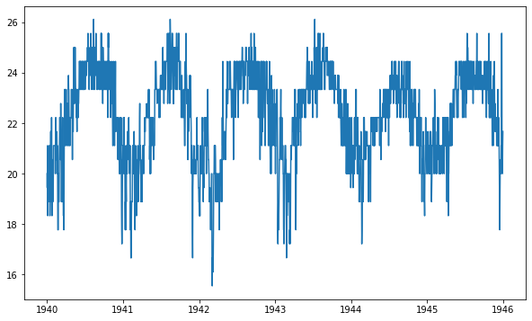

```python
fig, ax = plt.subplots()
_ = ax.plot(mtemps.index.values, mtemps.values)
# or equivalently
# mtemps.plot(ax=ax)
```

This plot tells us that:

- the series has a clear seasonality. We may have expected that: the temperatures raise during the summer and fall down in winter;
- while the highest temperature of the year remain constant (except for the year 1944) in the period 1940-1946, the lowest one increases in the late years;
- given the observed range, we can suppose that the temperature values are expressed in Celsius degrees.

#### Exercise 2.5

There are many strategies to address the forecasting task of a time series. The transformation of the series itself into a structured representation (i.e. a set of records sharing some predictive features) enables the use of machine learning models. We also know these models are trained to learn the function mapping predicting features to a desired value. Thus, to complete the design of a forecasting framework, we need to carefully select a target variable.

ML practitioners often use the following strategy:

- predictive features: the features to be used in the structured representation are computed from the values already observed from the series. They can be the values themselves (which makes the approach more similar to classical, statistical autoregressive models like [ARIMA](https://people.duke.edu/~rnau/411arim.htm)), or a more complex combination of them. In this exercise, we will adopt the simpler way and use the values in a window of fixed-length W. Specifically, this window will be rolling along the series, to obtain one record for each time step (for a graphical representation, please refer to the laboratory text);
- target variable: to model the task of forecasting, the target variable should encode a future event. Thus, the algorithm will be able to model the relationship between some already-seen feature values and an upcoming behavior of the series. In this exercise, we will use as target variable the value of the series right after the considered window.

```python
W = 3
X = list()
y = list()
```

```python
for i in range(mtemps.size - W): # range: [0, mtemps.size - W - 1]
    X.append(mtemps.iloc[i:i + W].values.T) # transpose to create a row array
    y.append(mtemps.iloc[i + W])

# transform the structured representation into numpy arrays
X = np.array(X)
y = np.array(y)
X.shape, y.shape
```

```
((2189, 3), (2189,))
```

We can check whether the rolling window has worked properly inspecting a few samples.

```python
mtemps[:5]
```

```
Date
1940-01-01    20.000000
1940-01-02    19.444444
1940-01-03    20.000000
1940-01-04    21.111111
1940-01-05    18.333333
Name: MeanTemp, dtype: float64
```

```python
X[:3,:]
```

```
array([[20.        , 19.44444444, 20.        ],
       [19.44444444, 20.        , 21.11111111],
       [20.        , 21.11111111, 18.33333333]])
```

```python
y[:3]
```

```
array([21.11111111, 18.33333333, 20.        ])
```

Given a record associated with the day *t*, `y[t]` is the value taken by the series at the day *t+W+1* (i.e. `mtemps[t+W]`), which seems correct.

#### Exercise 2.6

Let's use now the values from 1940 to 1944 as training data and test the model on the remaining year. We can leverage pandas to filter data based on time strings. To do so, we can convert our arrays into pandas DataFrame and Series using the DatetimeIndex from `mtemps`.

```python
X_df = pd.DataFrame(X, index=mtemps.index[:mtemps.size - W],
                    columns=["t0", "t1", "t2"])
X_df.head()
```

| Date | t0 | t1 | t2 |
| --- | --- | --- | --- |
| 1940-01-01 | 20.000000 | 19.444444 | 20.000000 |
| 1940-01-02 | 19.444444 | 20.000000 | 21.111111 |
| 1940-01-03 | 20.000000 | 21.111111 | 18.333333 |
| 1940-01-04 | 21.111111 | 18.333333 | 20.000000 |
| 1940-01-05 | 18.333333 | 20.000000 | 20.555556 |

```python
y_s = pd.Series(y, index=mtemps.index[:mtemps.size - W])
y_s.head()
```

```
Date
1940-01-01    21.111111
1940-01-02    18.333333
1940-01-03    20.000000
1940-01-04    20.555556
1940-01-05    18.888889
dtype: float64
```

```python
X_train, y_train = X_df.loc["1940":"1944"], y_s.loc["1940":"1944"]
X_train.index
```

```
DatetimeIndex(['1940-01-01', '1940-01-02', '1940-01-03', '1940-01-04',
               '1940-01-05', '1940-01-06', '1940-01-07', '1940-01-08',
               '1940-01-09', '1940-01-10',
               ...
               '1944-12-22', '1944-12-23', '1944-12-24', '1944-12-25',
               '1944-12-26', '1944-12-27', '1944-12-28', '1944-12-29',
               '1944-12-30', '1944-12-31'],
              dtype='datetime64[ns]', name='Date', length=1827, freq=None)
```

Keep in mind that we used a forward-looking notation for our window, i.e. for the record *t* we have the values of the series between *t* and *t+W*. Under this conditions, at the end of the year, we are going to have *W* data points that include information from the next year. This is not a problem up if we slightly shift the beginning of our test set. Specifically, we might want to start our test set for the *Wth* day or the year.

Including some information from what it is consider the test set into the training procedure is a wrong habit known as **data leakage**. You should always stop and take a moment to consider if any data leakage is happening within your pipeline.

```python
from datetime import date
initial_day = date(1944, 12, 31) + pd.Timedelta(f"{W} days")
initial_day
```

```
datetime.date(1945, 1, 3)
```

```python
X_test, y_test = X_df.loc[initial_day:], y_s.loc[initial_day:]
X_test.shape
```

```
(360, 3)
```

Note how neat is the indexing on pandas object with Datetime indices. You are allowed to specify a numpy-like interval with dates as `datetime.date` or strings. Of course, [more complex and useful indexings are possibile](https://pandas.pydata.org/pandas-docs/stable/user_guide/indexing.html), but they go beyond the scope of the laboratory.

#### Exercise 2.7

Since we still have in memory the definitions of `models` and `names` (this is one of the beauties and curses of Jupyter notebooks) we can recycle and them for our current task.

```python
t = PrettyTable()
t.field_names = ['model', 'MSE', 'R2']

for model, name in zip(models, names):
    model.fit(X_train, y_train)
    y_hat = model.predict(X_test)
    mse = mean_squared_error(y_test, y_hat)
    r2 = r2_score(y_test, y_hat)
    t.add_row([name, mse, r2])

print(t)
```

```
+------------------+--------------------+--------------------+
|      model       |        MSE         |         R2         |
+------------------+--------------------+--------------------+
|      linreg      | 0.7708838668711151 | 0.6684666582498298 |
|      ridge       | 0.7708190312576426 | 0.6684945420446823 |
|   mlp_standard   | 0.7756832982117083 | 0.6664025710646799 |
|    mlp_tuned     | 2.407530887487392  | -0.03540467610914  |
|       svr        | 0.7606632382515228 | 0.6728622349464781 |
|        rf        | 0.8362497037896549 | 0.6403548306695499 |
| sin+poly5+linreg | 1.1396245117527566 | 0.5098826957485592 |
| sin+poly5+ridge  | 1.1393130367062887 | 0.5100166515458784 |
+------------------+--------------------+--------------------+
```

Even in this case, the models with behavior more close to linear perform the better. This could imply that some sort of linear relationship exists between the past `W` values of the series and the target. Additional comments can be made:

- the choice of custom tuning of MLP is wrong in this case, since it lead to the worst performance. Keep in mind that we do not have carried out any validation. The validation step is used for hyperparameter tuning, iterating the training process to identify the best configurations. However, validating a machine learning approach based on time series requires further attention. Cross-validation is not allowed, for example, since values have an intrinsc order and cannot be shuffled. Scikit-learn offers a validation strategy for time series thourgh the [TimeSeriesSplit](https://scikit-learn.org/stable/modules/generated/sklearn.model_selection.TimeSeriesSplit.html) class. You can find complete examples on how to use it on the official documentation. The hyperparameter tuning can be mixed with TimeSeriesSplit the already seen [GridSearchCV](http://scikit-learn.sourceforge.net/stable/modules/generated/sklearn.grid_search.GridSearchCV.html).
- our approach is intentionally non incremental, i.e. we train the model once and we use it to forecast an entire future year. Although this is correct for research purposes, in practical applications we might find useful to fed fresh information to the model (e.g. by running the training again) as it comes, while the time passes by and new records are collected. The profitability of this approach, however, depends on the application (e.g. there are cases in which you are not able to train the model iteratively in time) and an improvement in performance should not be taken for granted.

#### Exercise 2.8

```
'The average |error| is: 0.65 +- 0.59 degrees Celsius'
```

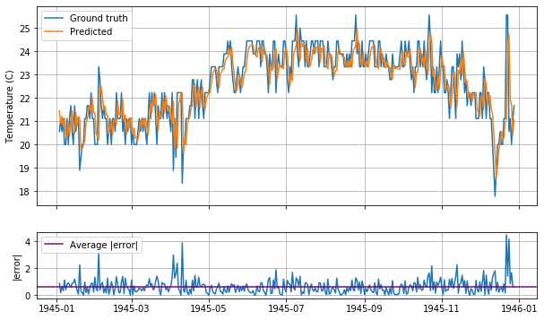

```python
model = Ridge(random_state=42)
model.fit(X_train, y_train)
y_hat = model.predict(X_test)
y_hat = pd.Series(y_hat, index=y_test.index)
error = y_test - y_hat

fig, ax = plt.subplots(nrows=2, ncols=1, sharex=True, gridspec_kw={'height_ratios': [3, 1]})
ax[0].plot(y_test, label="Ground truth")
ax[0].plot(y_hat, label="Predicted")
ax[0].set_ylabel("Temperature (C)")
ax[0].legend()
ax[0].grid()
ax[1].plot(error.abs())
ax[1].set_ylabel("|error|")
ax[1].axhline(error.abs().mean(), color="purple", label = "Average |error|")
ax[1].legend()
ax[1].grid()

f"The average |error| is: {error.abs().mean():.2f} +- {error.abs().std():.2f} degrees Celsius"
```

The figure shows that Ridge provides a good approximation but its predictions are somewhat lagged. The model takes at least one day to react to the current trend and so induces a non-zero error. On the bottom-end of the figure, the plot of residuals shows that the larger is the change in temperature w.r.t. the previous day (i.e. a high volatility among consecutive days is present), the larger is the error due to the lagged limitations of the estimator.

Even though these results suggest that the only values of the series are not sufficient to build a robust forecasting model (e.g. we may think that other, more expressive features are needed), the average absolute error 0.65 and the standard deviation is 0.59, which may be acceptable values for our domain after all.

Predicting a value further than one day ahead is not possibile at the moment, but many strategies exist to expand the forecast horizon. For example, one can train different models on different target variables: one encoding the value one day ahead (i.e. what we have done here), one with the value two days ahead as target, and so on. In this experimental setting, you would end up having one model per horizon step, which could add some computational cost.

#### Exercise 2.9

As a further exercise, we leave to you the tweaking of this pipeline to test and visually assess the performance of the remaining regressors.